# 数据预处理

人民大学-钟保罗-2019101155

2019-11-10

# 鲍鱼数据数据预处理

UCI鲍鱼数据含有4177只鲍鱼的观测。其中，被解释变量是Rings（环的个数），鲍鱼年龄是环的个数加1.5。其他变量为预测变量。

## 1)数据预览

对数据作图估计预测变量和被解释变量之间的函数关系。

由下图可以看出随着解释变量数值的增加，被解释变量也有增加的趋势。

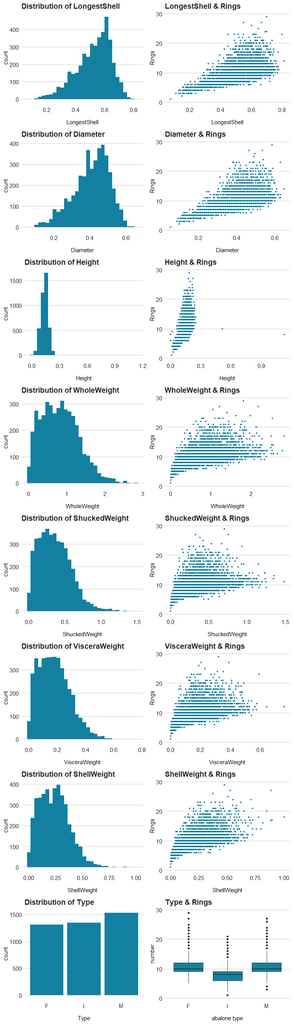

## 2)相关性探究

用散点图和相关系数图解释预测变量之间的相关性。

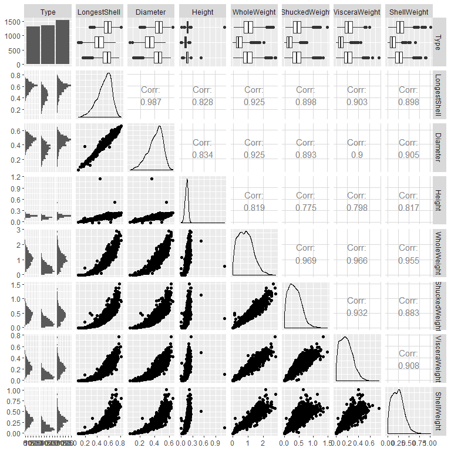

从散点图来看，各变量间存在强相关性。

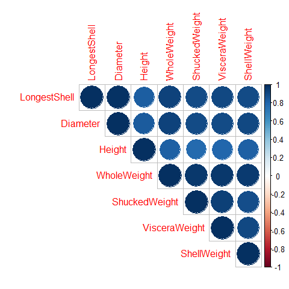

从相关系数图来看，各变量间的相关系数很大。

## 3)变量选择

对预测变量估计**重要性得分**。找到一种筛选方法得到**预测变量子集**，该集合不含冗余变量。

因为各个变量之间和被解释变量间为线性关系，所以用pearson相关系数来衡量解释变量重要性。因为type变量为因子型变量，因此进行one-hot编码。

其相关系数如下所示：

```
##      LongestShell  Diameter    Height WholeWeight ShuckedWeight
## [1,]    0.5567196 0.5746599 0.5574673   0.5403897     0.4208837
##      VisceraWeight ShellWeight    type_F     type_I    type_M
## [1,]     0.5038192    0.627574 0.2502787 -0.4360633 0.1818306
```

使用逐步回归的方法筛选变量，发现逐步回归法剔除了 Type_F，Type_M，LongestShell

逐步回归的模型结果如下：

```
##
## Call:
## lm(formula = Rings ~ Diameter + Height + WholeWeight + ShuckedWeight +
##     VisceraWeight + ShellWeight + type_I, data = mydata)
##
## Residuals:
##      Min       1Q   Median       3Q      Max
## -10.4765  -1.3056  -0.3400   0.8635  13.9285
##
## Coefficients:
##                Estimate Std. Error t value Pr(>|t|)
## (Intercept)     3.91573    0.26740  14.644  < 2e-16 ***
## Diameter       10.53830    0.98778  10.669  < 2e-16 ***
## Height         10.72512    1.53476   6.988 3.23e-12 ***
## WholeWeight     8.97433    0.72522  12.375  < 2e-16 ***
## ShuckedWeight -19.76904    0.81340 -24.304  < 2e-16 ***
## VisceraWeight -10.64815    1.28672  -8.275  < 2e-16 ***
## ShellWeight     8.74968    1.12398   7.785 8.76e-15 ***
## type_I         -0.86066    0.08938  -9.629  < 2e-16 ***
## ---
## Signif. codes:  0 '***' 0.001 '**' 0.01 '*' 0.05 '.' 0.1 ' ' 1
##
## Residual standard error: 2.194 on 4169 degrees of freedom
## Multiple R-squared:  0.5378, Adjusted R-squared:  0.537
## F-statistic: 693.1 on 7 and 4169 DF,  p-value: < 2.2e-16
```

## 4)主成分提取

这里对连续型变量进行主成分分析，发现碎石图中转折点出现在第二个主成分上，且第一个主成分已经可以解释90%的方差，因此只选择一个主成分就够了

```
## Importance of components:
##                           Comp.1     Comp.2     Comp.3      Comp.4
## Standard deviation     0.5814549 0.06295301 0.05391677 0.032475403
## Proportion of Variance 0.9741007 0.01141839 0.00837567 0.003038652
## Cumulative Proportion  0.9741007 0.98551912 0.99389479 0.996933440
##                             Comp.5      Comp.6       Comp.7
## Standard deviation     0.022125701 0.020656362 0.0121698919
## Proportion of Variance 0.001410477 0.001229361 0.0004267222
## Cumulative Proportion  0.998343916 0.999573278 1.0000000000
```

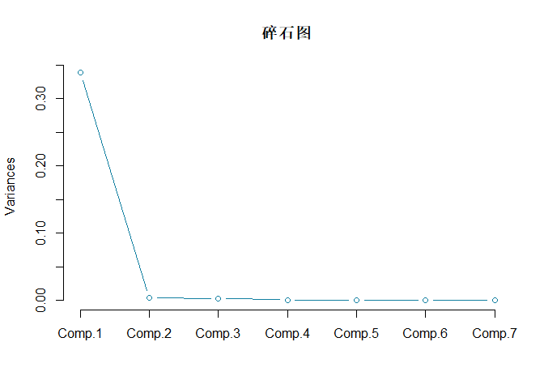

# 数据模拟

## 1)模拟数据生成

写一个 R 函数从该模型中模拟数据。 构建生成数据函数

```r
gen_data = function(min,max,mean,std,num){
  x1 = runif(num,min,max)
  x2 = runif(num,min,max)
  x3 = runif(num,min,max)
  x4 = runif(num,min,max)
  x5 = runif(num,min,max)
  y = 10*sin(pi*x1*x2)+20*(x3-0.5)^2+10*x4+5*x5+rnorm(num,mean,std)
  result = data.frame(x1,x2,x3,x4,x5,y)
  return(result)
}
```

## 2)研究变量间关系

Q: 随机模拟一个数据集，样本量是500，绘制图形研究预测变量和被解释变量之间的关系。

由图可知 x3与y 存在强关系

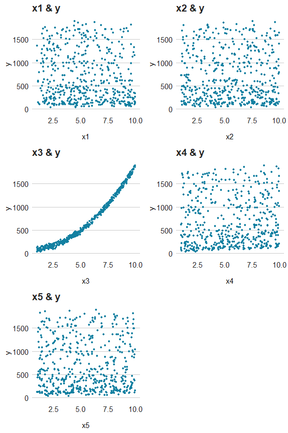

## 3)变量选择

向前法模型保留了所有变量

```r
model_for
```

```
##
## Call:
## lm(formula = y ~ x1 + x2 + x3 + x4 + x5, data = data_gen)
##
## Coefficients:
## (Intercept)           x1           x2           x3           x4
##   -446.6921       1.3522       0.5642     197.7922       6.6587
##          x5
##      5.8710
```

后退法模型保留了x3、x4、x5

```r
model_back
```

```
##
## Call:
## lm(formula = y ~ x3 + x4 + x5, data = data_gen)
##
## Coefficients:
## (Intercept)           x3           x4           x5
##    -435.347      197.643        6.683        5.838
```

逐步回归法模型保留了x3、x4、x5

```r
model_both
```

```
##
## Call:
## lm(formula = y ~ x3 + x4 + x5, data = data_gen)
##
## Coefficients:
## (Intercept)           x3           x4           x5
##    -435.347      197.643        6.683        5.838
```

## 4)过滤法

应用不同的过滤法，逐个评估变量。

### 1.方差

删除方差几乎为0的变量

如果一个变量方差为0，则其不会提供有用的信息，所以将方差为0的变量删去。

本文各个变量服从相同的分布，方差均不为零。变量方差如下：

```
## [1] 6.501929 6.981993 6.926511 7.297804 6.997237
```

### 2.强相关

去除强相关变量

变量间彼此相关会面临多重共线性，因此应该删掉这些变量，从下面的相关系数矩阵图可以看出，各变量间的相关性较小。

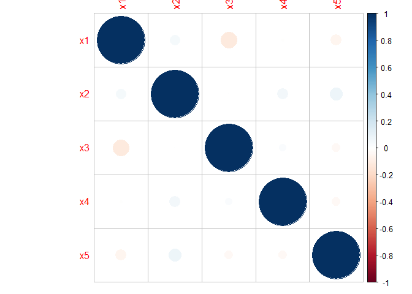

### 3.变量聚类

对变量聚类，分成不同组后，将不同组内的变量挑选几个，因为每个聚类分成额组内变量都十分相似，因此每个组只需要用一个变量代表即可，本次数据可以挑选x3、x5、x4

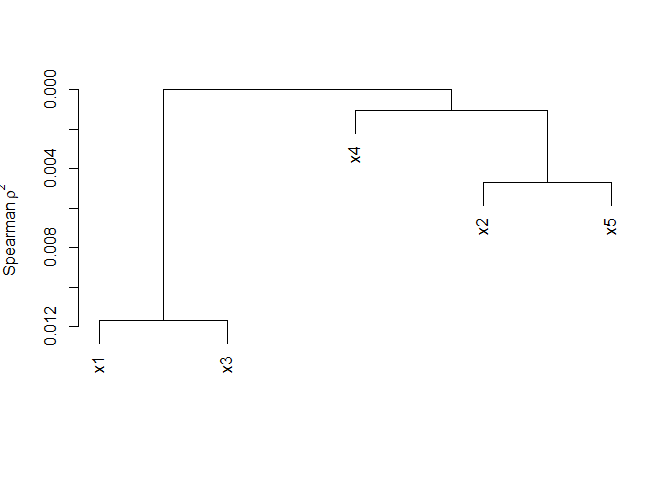

### 4.ReliefF算法

使用不同的统计量ReliefFequalK 和ReliefFexpRank，但是结果并不显著，各个变量间的重要性没有拉开差距。

也可以看出x1,x2有相同的倾向性，由于重要性相近，很难进行选择。 第一行为ReliefFequalK的值 第二行为ReliefFexpRank的值

```
##        x1        x2        x3        x4        x5
## 0.8599863 0.8669375 0.8618523 0.8706381 0.8640406
```

```
##        x1        x2        x3        x4        x5
## 0.8601919 0.8708118 0.8647687 0.8672150 0.8697738
```

### 5.loess评分

设置不同的阈值可以得出不同的变量。

阈值选为0.05时只保留x3

loess表:

```
##        Overall
## x1 0.026420107
## x2 0.001470645
## x3 0.996703561
## x4 0.008283805
## x5 0.004728661
```

### 6.mic选择

此处若设置阈值为0.2，则只有一个变量符合。

mic值：

```
##              Y
## [1,] 0.1698246
## [2,] 0.1608335
## [3,] 1.0000000
## [4,] 0.1806415
## [5,] 0.1549335
```

# 附录：R代码

```r
library(AppliedPredictiveModeling)
library(ggplot2)
library(bbplot)
library(grid)
library(GGally)
library(corrplot)
library(MASS)
data(abalone)

vp = function(x, y) {
  viewport(layout.pos.row = x, layout.pos.col = y)
}
mytheme1 = bbc_style()+theme(axis.title = element_text(size = 11),axis.text = element_text(size = 11),
                             plot.title = element_text(size = 14),plot.subtitle = element_text(size = 12))
blue = "#1380A1"

# 1，鲍鱼数据
# (1)
p1=ggplot(abalone,aes(x=LongestShell,y=Rings))+geom_point(size=1,color = blue)+mytheme1+labs(title = 'LongestShell & Rings')
p1.1=ggplot(abalone,aes(x=LongestShell))+geom_histogram(fill = blue,bins = 30)+mytheme1+labs(title = 'Distribution of LongestShell')
p2=ggplot(abalone,aes(x=Diameter,y=Rings))+geom_point(size=1,color = blue)+mytheme1+labs(title = 'Diameter & Rings')
p2.1=ggplot(abalone,aes(x=Diameter))+geom_histogram(fill = blue,bins = 30)+mytheme1+labs(title = 'Distribution of Diameter')
p3=ggplot(abalone,aes(x=Height,y=Rings))+geom_point(size=1,color = blue)+mytheme1+labs(title = 'Height & Rings')
p3.1=ggplot(abalone,aes(x=Height))+geom_histogram(fill = blue,bins = 30)+mytheme1+labs(title = 'Distribution of Height')
p4=ggplot(abalone,aes(x=WholeWeight,y=Rings))+geom_point(size=1,color = blue)+mytheme1+labs(title = 'WholeWeight & Rings')
p4.1=ggplot(abalone,aes(x=WholeWeight))+geom_histogram(fill = blue,bins = 30)+mytheme1+labs(title = 'Distribution of WholeWeight')
p5=ggplot(abalone,aes(x=ShuckedWeight,y=Rings))+geom_point(size=1,color = blue)+mytheme1+labs(title = 'ShuckedWeight & Rings')
p5.1=ggplot(abalone,aes(x=ShuckedWeight))+geom_histogram(fill = blue,bins = 30)+mytheme1+labs(title = 'Distribution of ShuckedWeight')
p6=ggplot(abalone,aes(x=VisceraWeight,y=Rings))+geom_point(size=1,color = blue)+mytheme1+labs(title = 'VisceraWeight & Rings')
p6.1=ggplot(abalone,aes(x=VisceraWeight))+geom_histogram(fill = blue,bins = 30)+mytheme1+labs(title = 'Distribution of VisceraWeight')
p7=ggplot(abalone,aes(x=ShellWeight,y=Rings))+geom_point(size=1,color = blue)+mytheme1+labs(title = 'ShellWeight & Rings')
p7.1=ggplot(abalone,aes(x=ShellWeight))+geom_histogram(fill = blue,bins = 30)+mytheme1+labs(title = 'Distribution of ShellWeight')
p8=ggplot(abalone,aes(x=factor(Type),y=Rings))+geom_boxplot(fill = blue)+mytheme1+xlab("abalone type")+ylab("number")+labs(title = 'Type & Rings')
p8.1=ggplot(abalone,aes(x=Type))+geom_bar(fill = blue)+mytheme1+labs(title = 'Distribution of Type')
grid.newpage()
pushViewport(viewport(layout = grid.layout(8, 2)))
print(p1.1,vp = vp(1,1));print(p1,vp = vp(1,2))
print(p2.1,vp = vp(2,1));print(p2,vp = vp(2,2))
print(p3.1,vp = vp(3,1));print(p3,vp = vp(3,2))
print(p4.1,vp = vp(4,1));print(p4,vp = vp(4,2))
print(p5.1,vp = vp(5,1));print(p5,vp = vp(5,2))
print(p6.1,vp = vp(6,1));print(p6,vp = vp(6,2))
print(p7.1,vp = vp(7,1));print(p7,vp = vp(7,2))
print(p8.1,vp = vp(8,1));print(p8,vp = vp(8,2))



# (2)变量相关性
excp_Rings = colnames(abalone)[1:8]
#散点图
ggpairs(abalone[,excp_Rings])
#相关系数图
excp_Rings_Type = colnames(abalone)[2:8]
cordata=cor(abalone[,excp_Rings_Type])
corrplot(cordata,type = "upper")

# (3)变量选择
mydata = abalone
mydata$type_F = ifelse(mydata$Type=='F',1,0)
mydata$type_I = ifelse(mydata$Type=='I',1,0)
mydata$type_M = ifelse(mydata$Type=='M',1,0)
mydata = mydata[,c(2:12)]
cor(mydata$Rings,mydata[,c(1:7,9:11)])
lm_model0 = lm(Rings~.,data=mydata)
summary(lm_model0)
lm_both = step(lm_model0,direction = "both")
summary(lm_both)

# (4)主成分分析
data_ana = abalone[,c(2:8)]
prin_model = princomp(data_ana)
summary(prin_model)
screeplot(prin_model,type="lines",main="碎石图",col=blue)

# 二
#(1)模拟数据
gen_data = function(min,max,mean,std,num){
  x1 = runif(num,min,max)
  x2 = runif(num,min,max)
  x3 = runif(num,min,max)
  x4 = runif(num,min,max)
  x5 = runif(num,min,max)
  y = 10*sin(pi*x1*x2)+20*(x3-0.5)^2+10*x4+5*x5+rnorm(num,mean,std)
  result = data.frame(x1,x2,x3,x4,x5,y)
  return(result)
}
#(2)生成数据
data_gen = gen_data(1,10,0,1,500)
p1=ggplot(data_gen,aes(x=x1,y=y))+geom_point(size=1,color = blue)+mytheme1+labs(title = 'x1 & y')
p2=ggplot(data_gen,aes(x=x2,y=y))+geom_point(size=1,color = blue)+mytheme1+labs(title = 'x2 & y')
p3=ggplot(data_gen,aes(x=x3,y=y))+geom_point(size=1,color = blue)+mytheme1+labs(title = 'x3 & y')
p4=ggplot(data_gen,aes(x=x4,y=y))+geom_point(size=1,color = blue)+mytheme1+labs(title = 'x4 & y')
p5=ggplot(data_gen,aes(x=x5,y=y))+geom_point(size=1,color = blue)+mytheme1+labs(title = 'x5 & y')
grid.newpage()
pushViewport(viewport(layout = grid.layout(3, 2)))
print(p1,vp = vp(1,1));print(p2,vp = vp(1,2))
print(p3,vp = vp(2,1));print(p4,vp = vp(2,2))
print(p5,vp = vp(3,1))
#(3)
model0 = lm(y~.,data = data_gen)
summary(model0)
model_for = step(model0,direction = 'forward')
model_back = step(model0,direction = 'backward')
model_both = step(model0,direction = 'both')

# (4)过滤法


# (4) 过滤法
# 删除方差几乎为0的变量,本文各个变量服从相同的分布，所以方差都近似相同
var_var=c()
for (i in 1:5) {
  var_var[i]=var(data_gen[,i])
}

# 去除强相关变量
cormatrix=cor(data_gen[,-6])
corrplot(cormatrix)

#变量聚类
library(Hmisc)
tmp=varclus(as.matrix(data_gen[,setdiff(names(data_gen),c('y'))]))
plot(tmp)

#relieff选择
library(caret)
library(CORElearn)
reliefValues=attrEval(y ~ .,data = data_gen,estimator = "ReliefFequalK",ReliefIterations = 50)
reliefValues1=attrEval(y ~ .,data = data_gen,estimator = "ReliefFexpRank",ReliefIterations = 50)
#也可以看出x1,x2有相同的倾向性，由于重要性相近，很难进行选择。
reliefValues
reliefValues1

#非过滤法，loess选择,但可以看出x1,x2基本由相同的倾向性
loessresult=filterVarImp(x=data_gen[,-6],y=data_gen[,6],nonpara=TRUE)
loessresult
loessresult=loessresult$Overall[loessresult$Overall>=0.05]
loessresult

#mic选择
library(minerva)
micValues1 = mine(data_gen[, -6],data_gen[,6])
data3=as.data.frame(micValues1$MIC)
micValues1$MIC
```